# ESM 204 Assignment 4

Anna Talken, Sydney Rilum & Grace Kumaishi

5/18/2021

```r
# Read in data:
damages <- read.csv(here("damages.csv"))
warming <- read.csv(here("warming.csv"))
```

## Question 1:

### Estimate the quadratic damage function:

```r
# Visualize points:
# ggplot(data = damages, aes(x = warming, y = damages)) +
  # geom_point()

# Create a new data frame for warming^2:
damages$warming2 <- damages$warming^2

# Fit quadratic regression model:
quadratic.model <-lm(damages ~ warming + warming2 + 0, data = damages)
```

#### Estimated damages quadratic model:

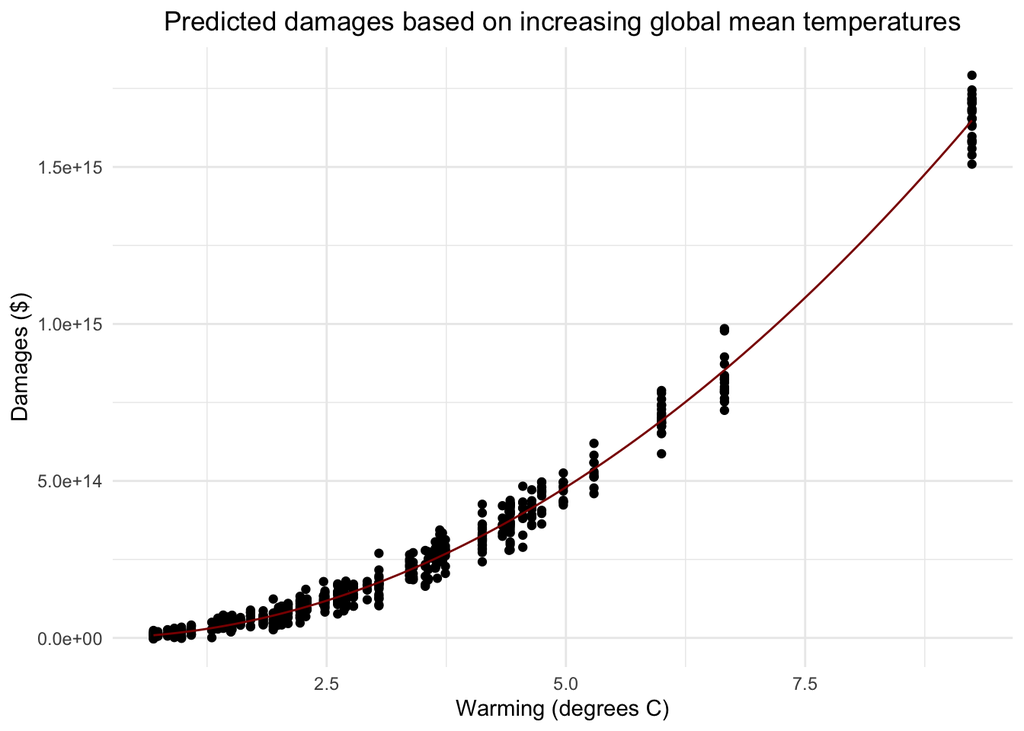

```r
# Create a function to graph quadratic damages model
damages_model <- function(w){
  d <- quadratic.model$coefficients[["warming2"]]*w^2 + quadratic.model$coefficients[["warming"]]*w + 0
  return(d)
}

### Plot estimated damage:
x = damages$warming
a = 1.959e+13
b = -1.03e+12
y = a * x^2 + b * x

ggplot(data = damages, aes(x = warming, y = damages)) +
  geom_point() +
  stat_function(fun = damages_model, color = "darkred")+
  theme_minimal()+
  labs(title = "Predicted damages based on increasing global mean temperatures",
       x = "Warming (degrees C)",
       y = "Damages ($)") +
  theme(plot.title = element_text(hjust = 0.5))
```

## Question 2

### 1) Plot damages over time without pulse:

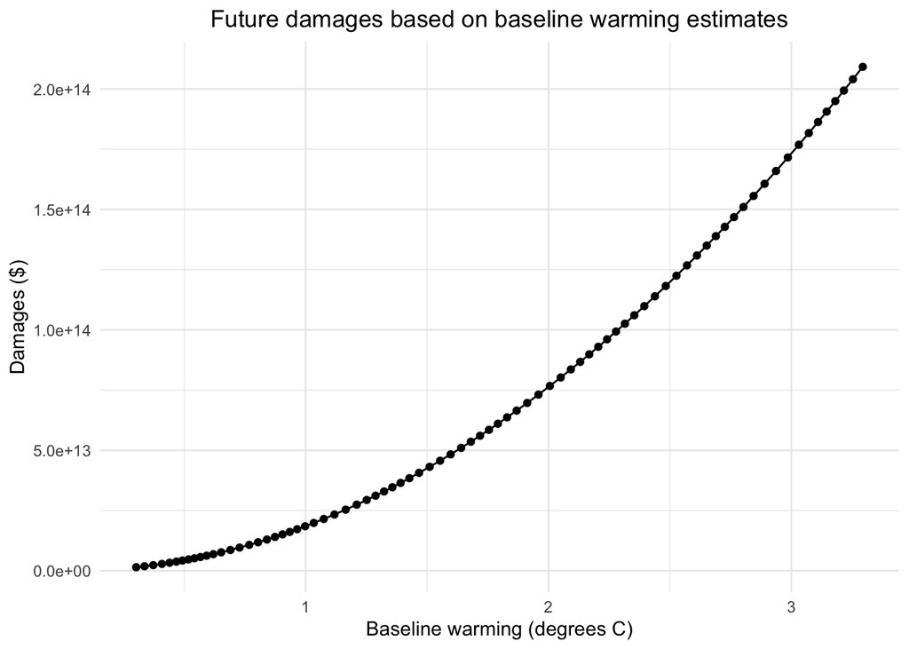

```r
# Create new function to calculate damages based on damages quadratic equation (didn't actually need this....):
damages <- function(w, model){
  d <- model$coefficients[[3]]*w^2 + model$coefficients[[2]]*w
  return(d)
}

# Cost of damages based on baseline climate scenario:

warming <- warming %>%
  mutate(damages_baseline = a*warming_baseline^2 + b*warming_baseline,
         damages_pulse = a*warming_pulse^2 + b*warming_pulse,
         dif_pulse = damages_pulse - damages_baseline,
         dif_pulse_perton = dif_pulse/35000000000)

ggplot(data = warming, aes(x = warming_baseline, y = damages_baseline)) +
  geom_point() +
  geom_line() +
  theme_minimal() +
  labs(title = "Future damages based on baseline warming estimates",
       x = "Baseline warming (degrees C)",
       y = "Damages ($)") +
  theme(plot.title = element_text(hjust = 0.5))
```

### 2) Plot damages over time with the pulse:

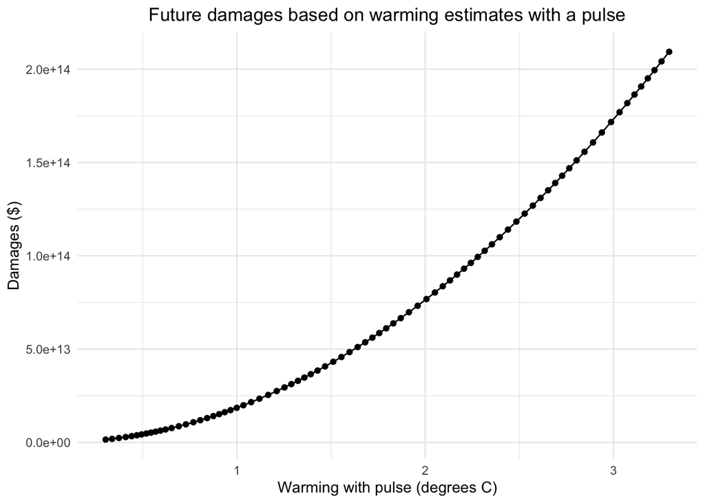

```r
ggplot(data = warming, aes(x = warming_pulse, y = damages_pulse)) +
  geom_point() +
  geom_line() +
  theme_minimal() +
  labs(title = "Future damages based on warming estimates with a pulse",
       x = "Warming with pulse (degrees C)",
       y = "Damages ($)") +
  theme(plot.title = element_text(hjust = 0.5))
```

### 3) Difference in damages over time that arise from pulse:

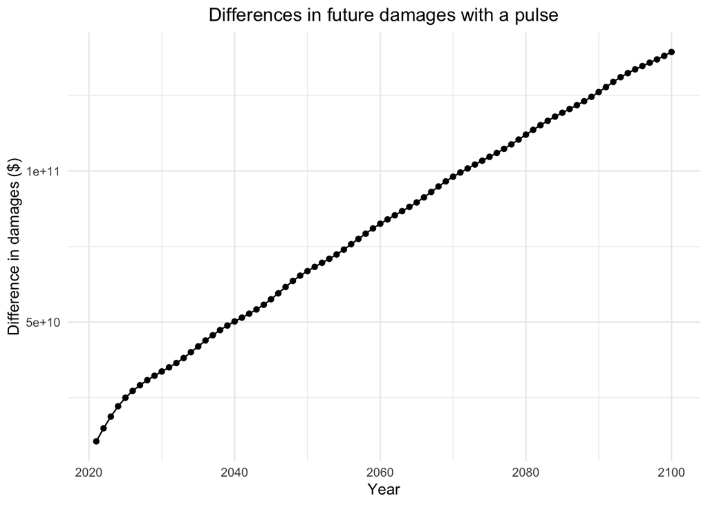

```r
ggplot(data = warming, aes(x = year, y = dif_pulse)) +
  geom_point() +
  geom_line() +
  theme_minimal() +
  labs(title = "Differences in future damages with a pulse",
       x = "Year",
       y = "Difference in damages ($)") +
  theme(plot.title = element_text(hjust = 0.5))
```

### 4) Difference in damages over time from the pulse per ton of CO2:

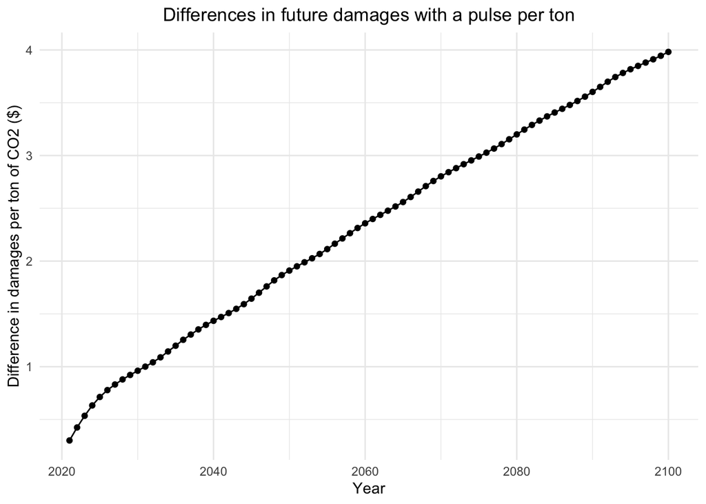

```r
ggplot(data = warming, aes(x = year, y = dif_pulse_perton)) +
  geom_point() +
  geom_line() +
  theme_minimal() +
  labs(title = "Differences in future damages with a pulse per ton",
       x = "Year",
       y = "Difference in damages per ton of CO2 ($)") +
  theme(plot.title = element_text(hjust = 0.5))
```

## Question 3:

#### Use the equation: `V0 = Vt / (1 + r)^t`

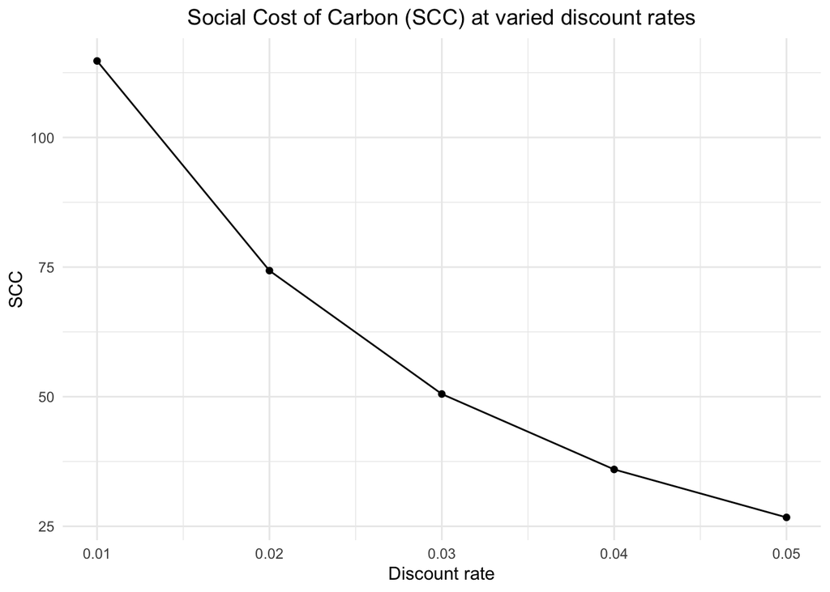

```r
# Create vector with 5 different discount rates:
rate <- c(0.01, 0.02, 0.03, 0.04, 0.05)

# Vt/(1+r)^t

SCC <- c()
for (i in 1:length(rate)) {
    cost <- (warming$dif_pulse_perton)/(1 + rate[i])^(warming$X)
    SCC[i] <- sum(cost)
  }

# Create table with SCC for each discount rate:
SCC_table <- round(data.frame("discount_rates" = rate,
                        "SCC" = SCC), 2)

# Graph discount rate vs. SCC:
ggplot(data = SCC_table, aes(x = rate,
                             y = SCC)) +
  geom_point() +
  geom_line() +
  theme_minimal() +
  labs(title = "Social Cost of Carbon (SCC) at varied discount rates",
       x = "Discount rate",
       y = "SCC") +
  theme(plot.title = element_text(hjust = 0.5))
```

## Question 4:

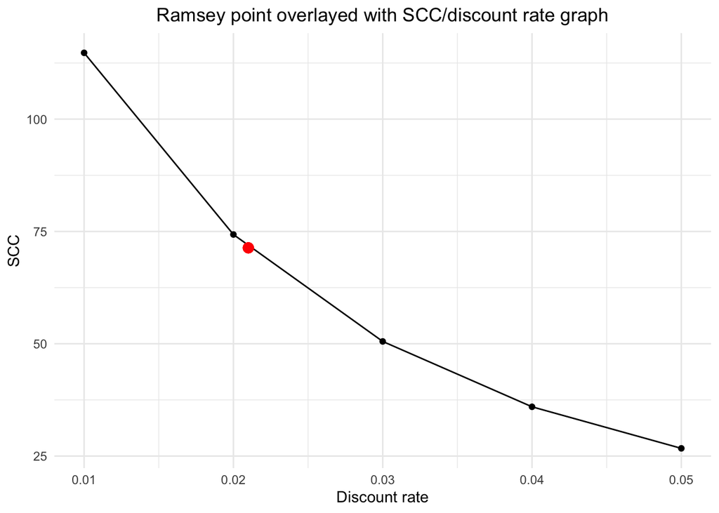

```r
# r = p +ng
ramsey = 0.021

# Create vector with 5 different discount rates:
ramsey_rate <- c(0.01, 0.02, 0.03, 0.04, 0.05, ramsey)

# Vt/(1+r)^t

SCC_ramsey <- c()
for (i in 1:length(ramsey_rate)) {
    cost_ramsey <- (warming$dif_pulse_perton)/(1 + ramsey_rate[i])^(warming$X)
    SCC_ramsey[i] <- sum(cost_ramsey)
}

SCC_table_ramsey <- data.frame("discount_rates" = ramsey_rate,
                        "SCC" = SCC_ramsey)

### Based on the output from the table above, we know that the new SCC value should be 71.35 ###

# Graph ramsey discount rate vs. SCC:
ggplot(data = SCC_table, aes(x = rate,
                             y = SCC)) +
  geom_point() +
  geom_line() +
  geom_point(x = 0.021, y = 71.35061, color = "red", size = 3) +
  theme_minimal() +
  labs(title = "Ramsey point overlayed with SCC/discount rate graph",
       x = "Discount rate",
       y = "SCC") +
  theme(plot.title = element_text(hjust = 0.5))
```

The Ramsey Rule was used to find a discount rate of 0.021, and an associated SCC of 71.35.

## Question 5:

### What is the expected present value of damages up to 2100 under Policy A?

```r
# Create data series for policy A new scenario (warming each year will be 1.5 times that in the “baseline” dataset)
warming <- warming %>%
  mutate(warming_baseline_x1.5 = warming_baseline*1.5) %>% # new warming data
  mutate(damages_baseline_x1.5 = damages_model(warming_baseline_x1.5)) # new damages data

# Calculate PV for each of policy A's scenarios with a discount rate of 2%
# Vt/(1+r)^t
```

Present Value of Outcome 1 (warming will occur as in the “baseline”) is **$1.87e+15.**

```r
# PV outcome 1 (warming will occur as in the “baseline”)
PV_A_baseline <- sum((warming$damages_baseline)/((1+0.02)^warming$X))
```

Present Value of Outcome 2 (warming each year will be 1.5 times that in the “baseline” dataset) is **$4.21e+15.**

```r
# PV outcome 2 (warming each year will be 1.5 times that in the “baseline” dataset)
PV_A_baseline_x1.5 <- sum((warming$damages_baseline_x1.5)/((1+0.02)^warming$X))
```

Under Policy A, the expected present value of damages up to 2100 is **$3.04e+15.**

```r
# Calculate expected value of damages for policy A scenarios with probability 0.5 for each
policy_A_expected_value <- (PV_A_baseline*0.5) + (PV_A_baseline_x1.5*0.5)
```

### What is the expected present value of damages up to 2100 under Policy B?

Under Policy B, the expected present value of damages up to 2100 is **$7.78e+14.**

```r
# Create data series for policy B scenario (Warming will continue until 2050 as in the “baseline” dataset, and then will stabilize at 1.29 degrees and stay that way forever)
warming <- warming %>%
  mutate(warming_baseline_2050 = case_when(
    year > 2050 ~ 1.29,
    TRUE ~ warming_baseline
  )) %>%
  mutate(damages_baseline_2050 = damages_model(warming_baseline_2050))

# Calculate PV with a discount rate of 2%
# Note: Policy B only has one outcome, therefore PV = Expected value
policy_B_expected_value <- sum((warming$damages_baseline_2050)/((1+0.02)^warming$X))
```

### If Policy A costs $0 and Policy B costs $X, how large could X be for it to still make economic sense to pursue Policy B instead of A?

```r
X = policy_A_expected_value - policy_B_expected_value
```

X would have to be less than **$2.26507e+15** in order for it to still make economic sense to pursue Policy B instead of Policy A.

### How would your answer change if society were risk averse?

If society was risk averse, then Policy B would be still be more attractive than Policy A because the expected value of Policy B is certain while the expected value of Policy A is uncertain (2 possible scenarios).